# Creating images with R

with a little bit of magick

Siqi Lai

```css
body {
font-family: comic sans MS;
background-color: #EFEAFF ;
}

h2 {
color: black;
font-weight: bold;
}

pre {
background-color: #CDBDFF;
}
```

## Project requirements

The project that I created it develop creativity of making meme with different function, create a website with different function in css. I used Markdown to create HTML for web page. I used R Makrdown properly for creating the web pages such as modified the background color, font weight, font family and so on. I develop the new meme and modifying features of the inspo meme. The Github repo contains the required file. The RStudio project folder was created and used for the project and R code features use of comments, identing, and “white space”. A new meme has been created with R code and a new animated GIF has been created with R code as well. The project report meets the state requirements and all correct files were submitted for the project.

### Project Files

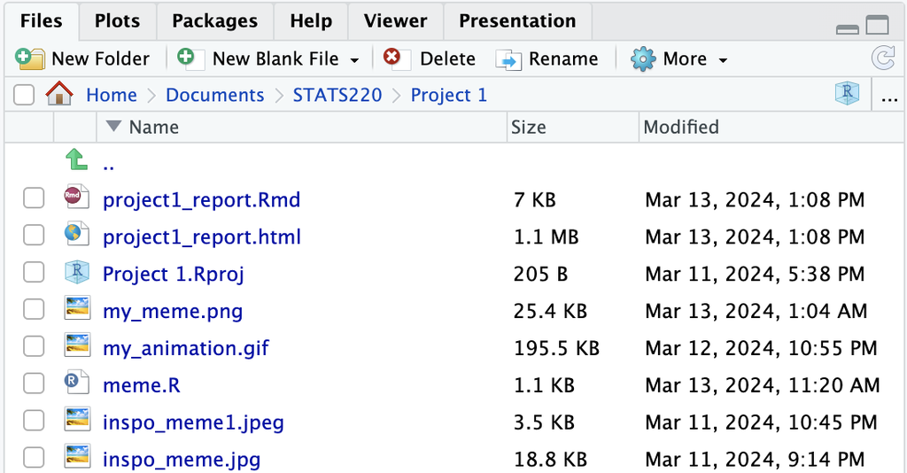

Repo:https://github.com/slai090/stats220/tree/main

Website:https://slai090.github.io/stats220/

## My meme

I re-created the “inspo” meme with the following key components and changes:

1. **First Cat Meme (`img1`):**
   - Loaded and scaled the first cat meme (“inspo_meme.jpg”) to 300 pixels using `image_scale`.
2. **First Square with Text (`img1_text`):**
   - Created a black square with a text annotation (“Ohno!”) at the center using `image_blank` and `image_annotate`.
3. **Second Cat Meme (`img2`):**
   - Loaded and scaled the second cat meme (“inspo_meme1.jpeg”) to 300 pixels using `image_scale`.
4. **Second Square with Text (`img2_text`):**
   - Created a black square with a text annotation (“emmmm”) at the center using `image_blank` and `image_annotate`.
5. **Combining Rows:**
   - Combined the first cat meme and its text annotation horizontally using `image_append` to create the top row (`top_row`).
   - Combined the second cat meme and its text annotation horizontally using `image_append` to create the bottom row (`bottom_row`).
6. **Combining Rows Vertically:**
   - Combined the two rows vertically using

     ```
     image_append(stack =
     TRUE)
     ```

     .
7. **Final Image Scaling:**
   - Scaled the final composite image to 500 pixels using `image_scale(500)`.

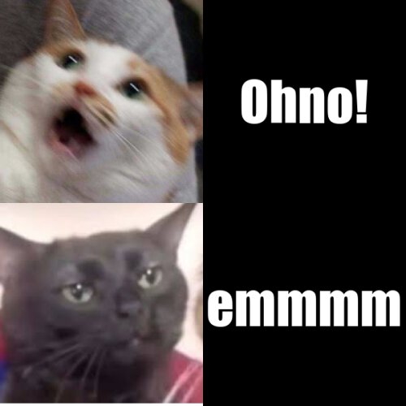

```r
# load first cat meme
img1 <- image_read("inspo_meme.jpg") %>%
  image_scale(300)

# first square
img1_text <- image_blank(width = 300,
                          height = 300,
                          color = "#000000") %>%
  image_annotate(text = "Ohno!",
                 color = "#FFFFFF",
                 size = 80,
                 font = "Impact",
                 gravity = "center")

# load second cat meme
img2 <- image_read("inspo_meme1.jpeg") %>%
  image_scale(300)

# second square
img2_text <- image_blank(width = 300,
                          height = 300,
                          color = "#000000") %>%
  image_annotate(text = "emmmm",
                 color = "#FFFFFF",
                 size = 80,
                 font = "Impact",
                 gravity = "center")

# making each row
# first using the approach we used above
cat_vector <- c(img1, img1_text)
top_row <- image_append(cat_vector)

# second using a different approach
bottom_row <- image_append(c(img2, img2_text))

# making the whole thing!

# using another approach
final_meme <- c(top_row, bottom_row) %>%
  image_append(stack = TRUE) %>%
  image_scale(500)
```

I re-created the animated meme with the following key components and changes:

1. **Cat Meme (`img1`):**
   - Loaded and scaled the cat meme (“inspo_meme.jpg”) to 300 pixels using `image_scale`.
2. **Animated Frames:**
   - Created four different frames (`img1_frame1`, `img1_frame2`, `img1_frame3`, `img1_frame4`) by annotating the meme with different texts.
   - Used `image_annotate` to add text to each frame.
   - Positioned the text at the bottom (`gravity = "south"`) for each frame.
3. **Animation Creation:**
   - Combined the frames into a vector (`img1_frames`).
   - Used `image_animate` to create an animated GIF (`img1_animation`) with a frame rate of 1 frame per second.

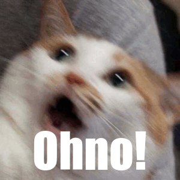

```r
# load meme gif
img1_frame1 <- img1 %>%
  image_annotate(text = "Ohno!",
                 color = "#FFFFFF",
                 size = 80,
                 font = "Impact",
                 gravity = "south")

img1_frame2 <- img1 %>%
  image_annotate(text = "No way!",
                 color = "#FFFFFF",
                 size = 80,
                 font = "Impact",
                 gravity = "south")

img1_frame3 <- img1 %>%
  image_annotate(text = "OMG!",
                 color = "#FFFFFF",
                 size = 80,
                 font = "Impact",
                 gravity = "south")

img1_frame4 <- img1 %>%
  image_annotate(text = "OHHHH",
                 color = "#FFFFFF",
                 size = 80,
                 font = "Impact",
                 gravity = "south")

# putting the fist meme frames in order using a vector
img1_frames <- c(img1_frame1, img1_frame2, img1_frame3, img1_frame4)

# creating an animation
img1_animation <- image_animate(img1_frames, fps = 1)
```

## Creativity

My project demonstrates creativity in several ways:

1. Different functions from the {magick} package such as `image_animate`, `image_append`, `image_annotate`
2. Fancy creation on meme such as animated GIF has 4 different status to express the meaning
3. More CSS on the appearance such as `background color`, `font weight`, `font family`
4. Fully describe the features in different bullet points such as ordered list and unordered list

## Learning reflection

I learned the skill of creating meme and animated memes using R code to modify features. I used many creative ideas for my meme creation and employ the functions effectively to generate images. Additionally, I learned the skill of HTML web pages by utilising various CSS codes, carefully constructing each section to enhance readability for users.

For exploring further, I like to study deeper into the data gathering, analysis, and model building. I want to expand my knowledge into purpose of utilising data. Furthermore, I am interested in exploring advanced techniques to create more complex HTML web pages using R code.